# SR Chapter 5

Now let’s simulate our variables and model.

```r
# first let simulate the variables; code 5.12 on page 134.. but as a tibble
N <- 100 # let's do 100 simulations
d <- tibble(
  A = rnorm(N, mean = 0, sd = 1),
  D = rnorm(N, mean = A, sd = 1),
  P = rnorm(N, mean = A, sd = 1)) %>% # simulating that A influences P only
  mutate(across(c(A,D,P),
                ~ (.x - mean(.x)) / sd(.x))) # standardizing to z scores
```

First, we will look at the correlation between Dancing and Puking
$$\begin{align}
Puking_i &\sim Normal(\mu_i, \sigma)\\
\mu_i &= \alpha + \beta_{Dancing}Dancing_i \\
\alpha &\sim Normal(0, 0.2)\\
\beta_{Dancing} &\sim Normal(0, 0.5)\\
\sigma &\sim Exponential(1)
\end{align}$$

```r
# start with just fitting puking and dancing
DP_sim <- quap(
  alist(
    P ~ dnorm(mu, sigma),
    mu <- a + bD * D,
    a ~ dnorm(0, 0.2),
    bD ~ dnorm(0, 0.5),
    sigma ~ dexp(1)
  ),
  data = d
)
precis(DP_sim)
```

```
##                mean         sd       5.5%     94.5%
## a     -5.038817e-07 0.07983480 -0.1275919 0.1275909
## bD     4.630063e-01 0.08622272  0.3252057 0.6008069
## sigma  8.707271e-01 0.06118660  0.7729391 0.9685151
```

$$\begin{align}
Puking_i &\sim Normal(\mu_i, \sigma)\\
\mu_i &= \alpha + \beta_{Alcohol}Alcohol_i \\
\alpha &\sim Normal(0, 0.2)\\
\beta_{Alcohol} &\sim Normal(0, 0.5)\\
\sigma &\sim Exponential(1)
\end{align}$$

```r
# now fit puking and alcohol consumption

AP_sim <- quap(
  alist(
    P ~ dnorm(mu, sigma),
    mu <- a + bA * A,
    a ~ dnorm(0, 0.2),
    bA ~ dnorm(0, 0.5),
    sigma ~ dexp(1)
  ),
  data = d
)
precis(AP_sim)
```

```
##               mean         sd       5.5%     94.5%
## a     2.914145e-07 0.07050351 -0.1126779 0.1126785
## bA    6.354631e-01 0.07489270  0.5157701 0.7551561
## sigma 7.533994e-01 0.05299338  0.6687058 0.8380931
```

Now, we go back to our original model:
$$\begin{align}
Puking_i &\sim Normal(\mu_i, \sigma)\\
\mu_i &= \alpha + \beta_{Dancing}Dancing_i +
\beta_{Alochol}Alochol_i\\
\alpha &\sim Normal(0, 0.2)\\
\beta_{Dancing} &\sim Normal(0, 0.5)\\
\beta_{Alochol} &\sim Normal(0, 0.5)\\
\sigma &\sim Exponential
\end{align}$$
Here’s the code to simulate that.

```r
# now let's simulate our entire model using puking, dancing, and alcohol
PAD_sim <- quap(
  alist(
    P ~ dnorm(mu, sigma),
    mu <- a + bD * D + bA * A,
    a ~ dnorm(0, 0.2),
    bD ~ dnorm(0, 0.5),
    bA ~ dnorm(0, 0.5),
    sigma ~ dexp(1)
  ),
  data = d
)
precis(PAD_sim)
```

```
##                mean         sd       5.5%     94.5%
## a     -9.344826e-07 0.07046182 -0.1126125 0.1126107
## bD     5.808808e-02 0.10280236 -0.1062099 0.2223861
## bA     5.956542e-01 0.10283437  0.4313051 0.7600034
## sigma  7.528907e-01 0.05296641  0.6682402 0.8375413
```

Now, let’s visualize these simulated results. I would use the code from the bookdown website, but it create its variables for ggplot using `brm` which we are not allowed to use. So instead I will use the code from the book.

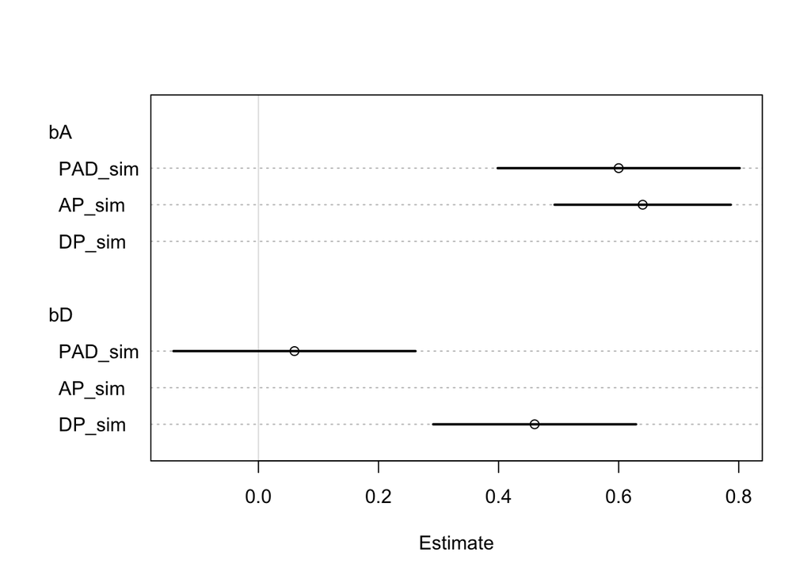

```r
# now let's plot and compare, again going to original code

plot(coeftab(DP_sim, AP_sim, PAD_sim), par = c("bA", "bD"), xlab = "Estimate")
```

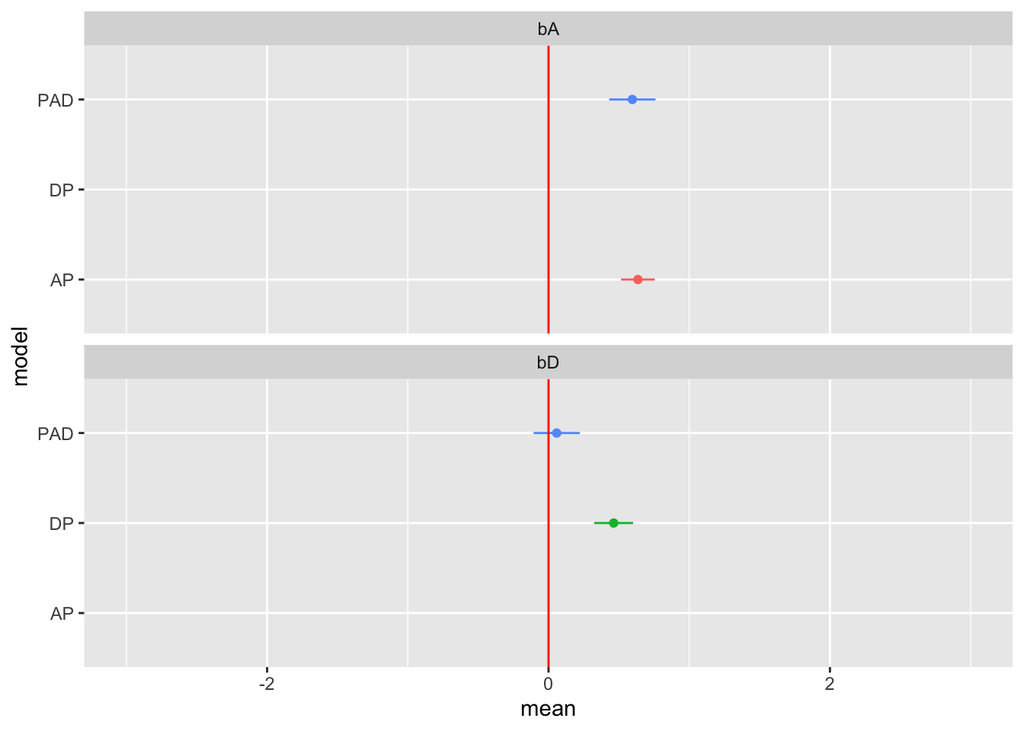

```r
# plot with the help of pablo doing in tidy way
models <- list(DP = DP_sim,
                 AP = AP_sim,
                 PAD = PAD_sim)

  # Function to extract coefficients
  coef_tbl <-
    lapply(1:length(models),function(x){
    tbl <- precis(models[[x]]) # Mean and compatibility intervals for coef
    model <- names(models)[x] # The name of the model the coefs are coming from

    # Put it together and return it
     tbl %>%
      as_tibble() %>%
      mutate(coef = rownames(tbl),
             model = model) %>%
      relocate(model,coef)
    }) %>%
    bind_rows()

# adding this so my graph only shows the two things I need
  coef_tbl <- coef_tbl %>%
    filter(coef == "bA" | coef == "bD")

  # Plot the coefficients, changed code to make it mirror OG model more
  coef_tbl %>%
  ggplot(aes(mean, model, color = model)) +
  geom_point() +
  geom_linerange(aes(xmin = `5.5%`, xmax = `94.5%`)) +
  geom_vline(aes(xintercept = 0), color = "red") +
  facet_wrap(~coef, nrow = 3) +
  theme(legend.position = "none") +
  xlim(-3, 3)
```

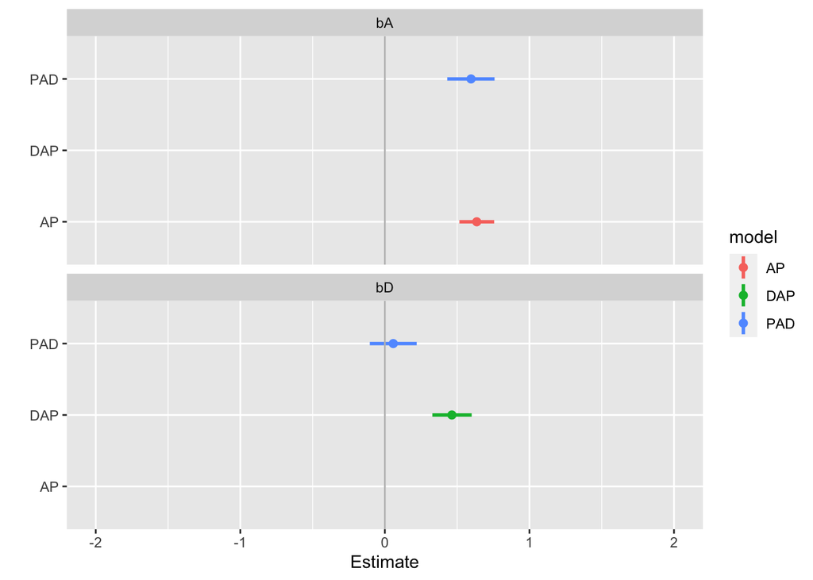

```r
  # trying the version from class

DP_post <- tidy_draws(DP_sim, n = 1e4) %>%
  select(bD)
AP_post <- tidy_draws(AP_sim, n = 1e4) %>%
  select(bA)
PAD_post <- tidy_draws(PAD_sim, n = 1e4) %>%
  select(bA, bD)


PAD_longpost <- PAD_post %>%
  pivot_longer(everything(),
               names_to = "term",
               values_to = "values")

PAD_postsum <- PAD_longpost |>
  group_by(term) |>
  summarize(mean = mean(values),
            lb = quantile(values, .055),
            ub = quantile(values, .945)) %>%
  mutate(model = "PAD")

AP_longpost <- AP_post %>%
  pivot_longer(everything(),
               names_to = "term",
               values_to = "values")

AP_postsum <- AP_longpost |>
  group_by(term) |>
  summarize(mean = mean(values),
            lb = quantile(values, .055),
            ub = quantile(values, .945)) %>%
  mutate(model = "AP")


DP_longpost <- DP_post %>%
  pivot_longer(everything(),
               names_to = "term",
               values_to = "values")

DP_postsum <- DP_longpost |>
  group_by(term) |>
  summarize(mean = mean(values),
            lb = quantile(values, .055),
            ub = quantile(values, .945)) %>%
  mutate(model = "DAP")

# this is my way of adding all of the values I need together for my plot
postsum <- full_join(DP_postsum, AP_postsum, by = c("model", "lb", "ub", "mean", "term"))
postsum <- full_join(postsum, PAD_postsum, by = c("model", "lb", "ub", "mean", "term"))

ggplot(postsum,
       aes(mean, model, color = model,
           xmin = lb,
           xmax = ub)) +
  geom_point(size = 2) +
  geom_linerange(size = 1) +
  geom_vline(xintercept = 0,
             color = "gray") +
  xlim(-2,2) +
  labs(x = "Estimate",
       y = "") +   facet_wrap(~term, nrow = 3)
```

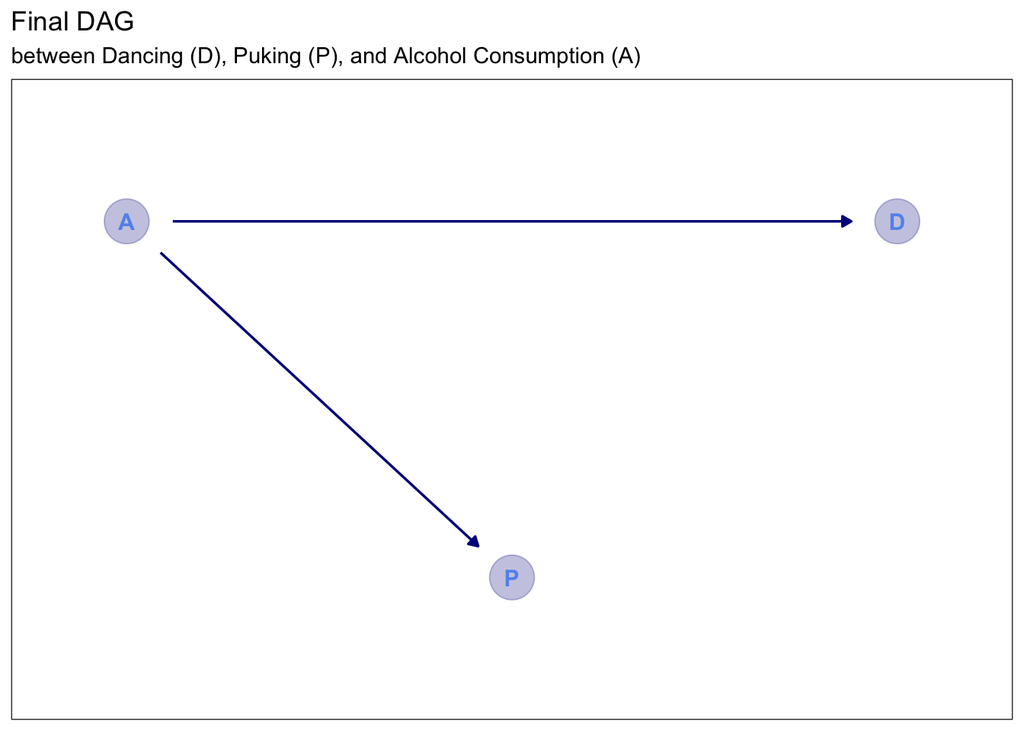

```r
dag_coords2 <-
  tibble(
    name = c("A", "D", "P"),
    x = c(1, 3, 2),
    y = c(2, 2, 1)
  )

p2 <-
  dagify(D ~ A, P ~ A,
    coords = dag_coords2
  ) %>%
  ggplot(aes(x = x, y = y, xend = xend, yend = yend)) +
  geom_dag_point(color = "blue4", alpha = 1 / 4, size = 10) +
  geom_dag_text(color = "cornflowerblue") +
  geom_dag_edges(edge_color = "blue4") +
  scale_x_continuous(NULL, breaks = NULL, expand = c(0.1, 0.1)) +
  scale_y_continuous(NULL, breaks = NULL, expand = c(0.2, 0.2)) +
  theme_bw() +
  theme(panel.grid = element_blank()) +
  labs(
    title = "Final DAG",
    subtitle = "between Dancing (D), Puking (P), and Alcohol Consumption (A)"
  )

p2
```

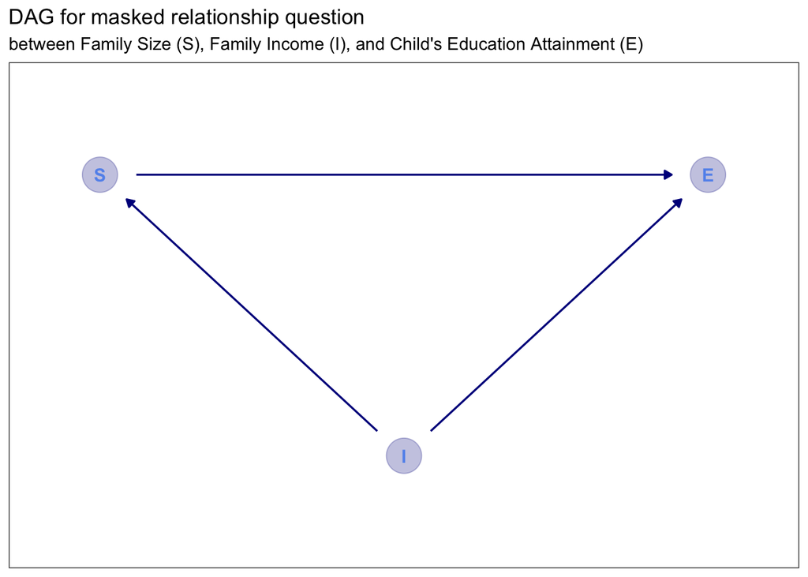

```r
# let's make a DAG first.

# checking conditional independencies
IES_dag1 <- dagitty("dag{S<-I->E<-S}")
impliedConditionalIndependencies(IES_dag1)
# there are none, so we see that there is no output

# load package needed to create tidy DAG
library(ggdag)

dag_coords3 <-
  tibble(
    name = c("S", "E", "I"),
    x = c(1, 3, 2),
    y = c(2, 2, 1)
  )

p3 <-
  dagify(S ~ I, E ~ S, E ~ I,
    coords = dag_coords3
  ) %>%
  ggplot(aes(x = x, y = y, xend = xend, yend = yend)) +
  geom_dag_point(color = "blue4", alpha = 1 / 4, size = 10) +
  geom_dag_text(color = "cornflowerblue") +
  geom_dag_edges(edge_color = "blue4") +
  scale_x_continuous(NULL, breaks = NULL, expand = c(0.1, 0.1)) +
  scale_y_continuous(NULL, breaks = NULL, expand = c(0.2, 0.2)) +
  theme_bw() +
  theme(panel.grid = element_blank()) +
  labs(
    title = "DAG for masked relationship question",
    subtitle = paste0(
      "between Family Size (S), Family Income (I), ",
      "and Child's Education Attainment (E)"
    )
  )

p3
```

Let’s start by creating our model definition with priors defined. I will use the ones from the book again.

$$\begin{align}
Education_i &\sim Normal(\mu_i, \sigma)\\
\mu_i &= \alpha + \beta_{Size}Size + \beta_{Income}Income\\
\alpha &\sim Normal(0, 0.2)\\
\beta_{Size} &\sim Normal(0, 0.5)\\
\beta_{Income} &\sim Normal(0, 0.5)\\
\sigma &\sim Exponential(1)
\end{align}$$

Now let’s simulate our variables and model. In both cases, when we have all predictors in the model the estimates move apart. (This is the top lin in bI and bS). This means that they both have a stronger association when they are in the same model, showing that the two variables are correlated with the outcome but in different directions.

```r
# first let simulate the variables; code 5.42 on page 152
n <- 100 # let's do 100 simulations
d2 <- tibble(
  I = rnorm(n, mean = 0, sd = 1),
  S = rnorm(n, mean = I, sd = 1),
  E = rnorm(n, mean = I - S, sd = 1)) %>%
   mutate(across(c(I,S,E),
                ~ (.x - mean(.x)) / sd(.x))) # standardizing to z scores
```

First, we will look at the correlation between Size and Education
$$\begin{align}
Education_i &\sim Normal(\mu_i, \sigma)\\
\mu_i &= \alpha + \beta_{Size}Size \\
\alpha &\sim Normal(0, 0.2)\\
\beta_{Size} &\sim Normal(0, 0.5)\\
\sigma &\sim Exponential(1)
\end{align}$$

```r
# start with just fitting child educaction and family size
ES_sim <- quap(
  alist(
    E ~ dnorm(mu, sigma),
    mu <- a + bS * S,
    a ~ dnorm(0, 0.2),
    bS ~ dnorm(0, 0.5),
    sigma ~ dexp(1)
  ),
  data = d2
)
precis(ES_sim)
```

```
##                mean         sd       5.5%      94.5%
## a     -1.686536e-09 0.06782490 -0.1083973  0.1083973
## bS    -6.724364e-01 0.07173777 -0.7870872 -0.5577856
## sigma  7.209728e-01 0.05072538  0.6399038  0.8020417
```

Now for Income and Education.
$$\begin{align}
Education_i &\sim Normal(\mu_i, \sigma)\\
\mu_i &= \alpha + \beta_{Income}Income_i \\
\alpha &\sim Normal(0, 0.2)\\
\beta_{Income} &\sim Normal(0, 0.5)\\
\sigma &\sim Exponential(1)
\end{align}$$

```r
# now fit child education and income

EI_sim <- quap(
  alist(
    E ~ dnorm(mu, sigma),
    mu <- a + bI * I,
    a ~ dnorm(0, 0.2),
    bI ~ dnorm(0, 0.5),
    sigma ~ dexp(1)
  ),
  data = d2
)
precis(EI_sim)
```

```
##                mean         sd       5.5%      94.5%
## a      4.212063e-08 0.08697986 -0.1390106  0.1390107
## bI    -2.122701e-01 0.09530596 -0.3645875 -0.0599528
## sigma  9.659287e-01 0.06781612  0.8575454  1.0743119
```

Now, again, we go back to our original model:
$$\begin{align}
Education_i &\sim Normal(\mu_i, \sigma)\\
\mu_i &= \alpha + \beta_{Size}Size_i + \beta_{Income}Income_i\\
\alpha &\sim Normal(0, 0.2)\\
\beta_{Size} &\sim Normal(0, 0.5)\\
\beta_{Income} &\sim Normal(0, 0.5)\\
\sigma &\sim Exponential(1)
\end{align}$$
Here’s the code to simulate that.

```r
# now let's simulate our entire model using  education, size, and income
IES_sim <- quap(
  alist(
    E ~ dnorm(mu, sigma),
    mu <- a + bS * S + bI * I,
    a ~ dnorm(0, 0.2),
    bS ~ dnorm(0, 0.5),
    bI ~ dnorm(0, 0.5),
    sigma ~ dexp(1)
  ),
  data = d2
)
precis(IES_sim)
```

```
##                mean         sd        5.5%       94.5%
## a     -4.542155e-08 0.05554249 -0.08876767  0.08876758
## bS    -1.125201e+00 0.08533558 -1.26158392 -0.98881845
## bI     6.094294e-01 0.08529520  0.47311123  0.74574765
## sigma  5.781676e-01 0.04083014  0.51291311  0.64342200
```

Again, let’s visually compare these models.

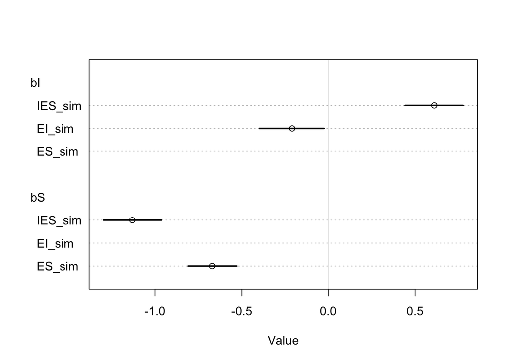

```r
# my original plot
plot(coeftab(ES_sim, EI_sim, IES_sim), pars = c("bI", "bS"))
```

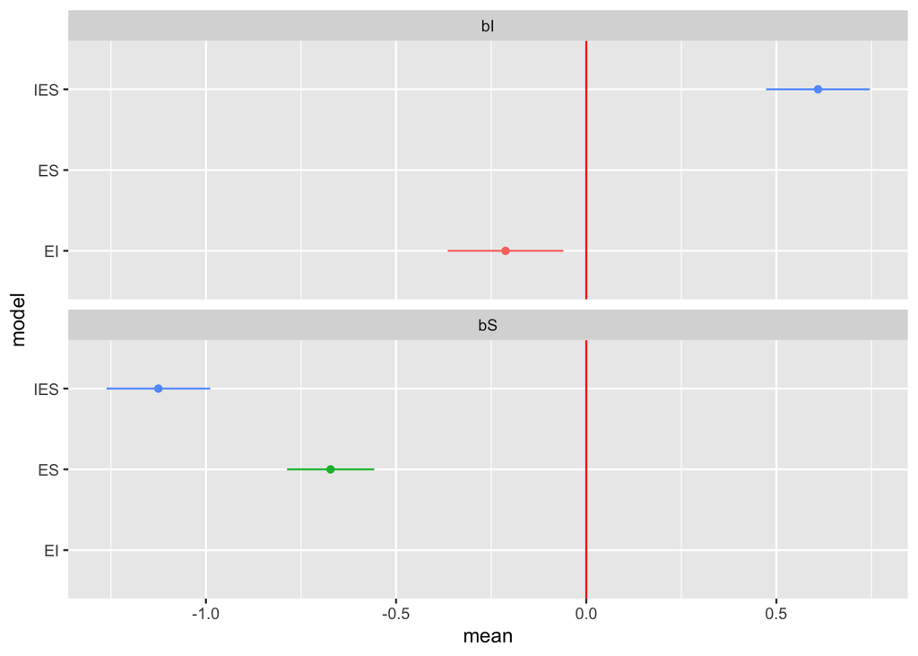

```r
# plot with the help of pablo doing in tidy way
models <- list(ES = ES_sim,
                 EI = EI_sim,
                 IES = IES_sim)

  # Function to extract coefficients
  coef_tbl <-
    lapply(1:length(models),function(x){
    tbl <- precis(models[[x]]) # Mean and compatibility intervals for coef
    model <- names(models)[x] # The name of the model the coefs are coming from

    # Put it together and return it
     tbl %>%
      as_tibble() %>%
      mutate(coef = rownames(tbl),
             model = model) %>%
      relocate(model,coef)
    }) %>%
    bind_rows()

# adding this so my graph only shows the two things I need
  coef_tbl <- coef_tbl %>%
    filter(coef == "bI" | coef == "bS")

  # Plot the coefficients, changed code to make it mirror OG model more
  coef_tbl %>%
  ggplot(aes(mean, model, color = model)) +
  geom_point() +
  geom_linerange(aes(xmin = `5.5%`, xmax = `94.5%`)) +
  geom_vline(aes(xintercept = 0), color = "red") +
  facet_wrap(~coef, nrow = 3) +
  theme(legend.position = "none")
```

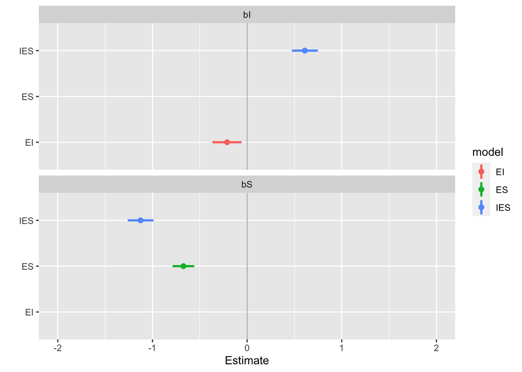

```r
  # again going to try workflow from class

ES_post <- tidy_draws(ES_sim, n = 1e4) %>%
  select(bS)
EI_post <- tidy_draws(EI_sim, n = 1e4) %>%
  select(bI)
IES_post <- tidy_draws(IES_sim, n = 1e4) %>%
  select(bS, bI)


IES_longpost <- IES_post %>%
  pivot_longer(everything(),
               names_to = "term",
               values_to = "values")

IES_postsum <- IES_longpost |>
  group_by(term) |>
  summarize(mean = mean(values),
            lb = quantile(values, .055),
            ub = quantile(values, .945)) %>%
  mutate(model = "IES")

EI_longpost <- EI_post %>%
  pivot_longer(everything(),
               names_to = "term",
               values_to = "values")

EI_postsum <- EI_longpost |>
  group_by(term) |>
  summarize(mean = mean(values),
            lb = quantile(values, .055),
            ub = quantile(values, .945)) %>%
  mutate(model = "EI")


ES_longpost <- ES_post %>%
  pivot_longer(everything(),
               names_to = "term",
               values_to = "values")

ES_postsum <- ES_longpost |>
  group_by(term) |>
  summarize(mean = mean(values),
            lb = quantile(values, .055),
            ub = quantile(values, .945)) %>%
  mutate(model = "ES")

# this is my way of adding all of the values I need together for my plot
postsum <- full_join(ES_postsum, EI_postsum, by = c("model", "lb", "ub", "mean", "term"))
postsum <- full_join(postsum, IES_postsum, by = c("model", "lb", "ub", "mean", "term"))

ggplot(postsum,
       aes(mean, model, color = model,
           xmin = lb,
           xmax = ub)) +
  geom_point(size = 2) +
  geom_linerange(size = 1) +
  geom_vline(xintercept = 0,
             color = "gray") +
  xlim(-2,2) +
  labs(x = "Estimate",
       y = "") +   facet_wrap(~term, nrow = 3)
```

We can now see here that with both bI and bS, there is a strong association when all variables are present in the model (see the top lines in both). We can see the lines are moving away from each other. This means that both related to the outcome variable (E), but one positively (bI) and one negatively (bS).

**5M3. It is sometimes observed that the best predictor of fire risk is the presence of firefighters— States and localities with many firefighters also have more fires. Presumably firefighters do not cause fires. Nevertheless, this is not a spurious correlation. Instead fires cause firefighters. Consider the same reversal of causal inference in the context of the divorce and marriage data. How might a high divorce rate cause a higher marriage rate? Can you think of a way to evaluate this relationship, using multiple regression?**

If people get divorced more, they may also then get married more just a second time. Therefore, let’s add this variable to the model (remarriage) and flip divorce to an explanatory variable and marriage as a dependent variable.(Since I have not learned about mediating relationships yet in a model this is just my rough idea of what would occur, not including priors). Additionally, here is a DAG.
$$\begin{align}
M_i &\sim Normal(\mu_i,\sigma)\\
\mu_i &= \alpha + \beta_DDi + \beta_RR_i\\
\end{align}$$

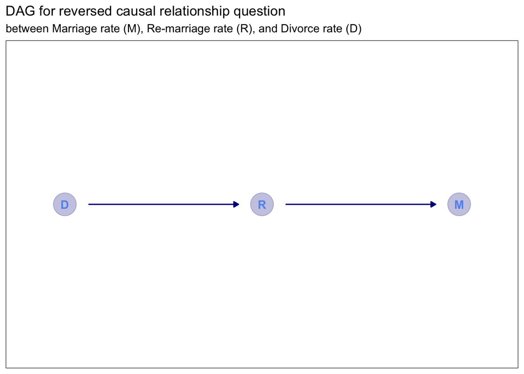

```r
dag_coords3 <-
  tibble(
    name = c("M", "D", "R"),
    x = c(3, 1, 2),
    y = c(2, 2, 2)
  )

p4 <-
  dagify(M ~ R, R ~ D,
    coords = dag_coords3
  ) %>%
  ggplot(aes(x = x, y = y, xend = xend, yend = yend)) +
  geom_dag_point(color = "blue4", alpha = 1 / 4, size = 10) +
  geom_dag_text(color = "cornflowerblue") +
  geom_dag_edges(edge_color = "blue4") +
  scale_x_continuous(NULL, breaks = NULL, expand = c(0.1, 0.1)) +
  scale_y_continuous(NULL, breaks = NULL, expand = c(0.2, 0.2)) +
  theme_bw() +
  theme(panel.grid = element_blank()) +
  labs(
    title = "DAG for reversed causal relationship question",
    subtitle = paste0(
      "between Marriage rate (M), ",
      "Re-marriage rate (R), and Divorce rate (D)"
    )
  )
# what's confusing for me though is if re-marriage rates would be
# compiled into marriage rates? In my model I will say it does, but would it?

p4
```

**5M4. In the divorce data, States with high numbers of members of the Church of Jesus Christ of Latter-day Saints (LDS) have much lower divorce rates than the regression models expected. Find a list of LDS population by State and use those numbers as a predictor variable, predicting divorce rate using marriage rate, median age at marriage, and percent LDS population (possibly standardized). You may want to consider transformations of the raw percent LDS variable.**

First, let’s load in data from https://worldpopulationreview.com/state-rankings/mormon-population-by-state.

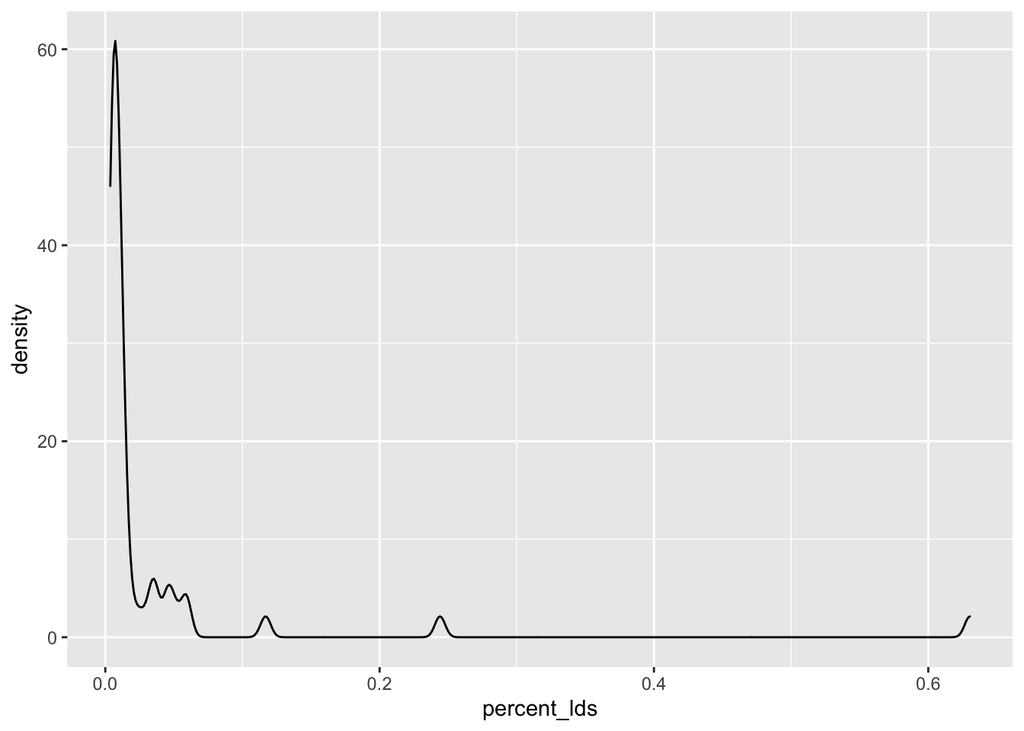

```r
LDS_data <- read.csv("/Users/allysoncameron/Desktop/soc_722_stats/Data/LDS.csv")

# creating percentage and selecting only state and %
LDS_data <- LDS_data %>%
  mutate(percent_lds = mormonPop/Pop) %>%
  select(State, percent_lds)

# let's look at the percentages
ggplot(LDS_data, aes(x = percent_lds)) + geom_density()
```

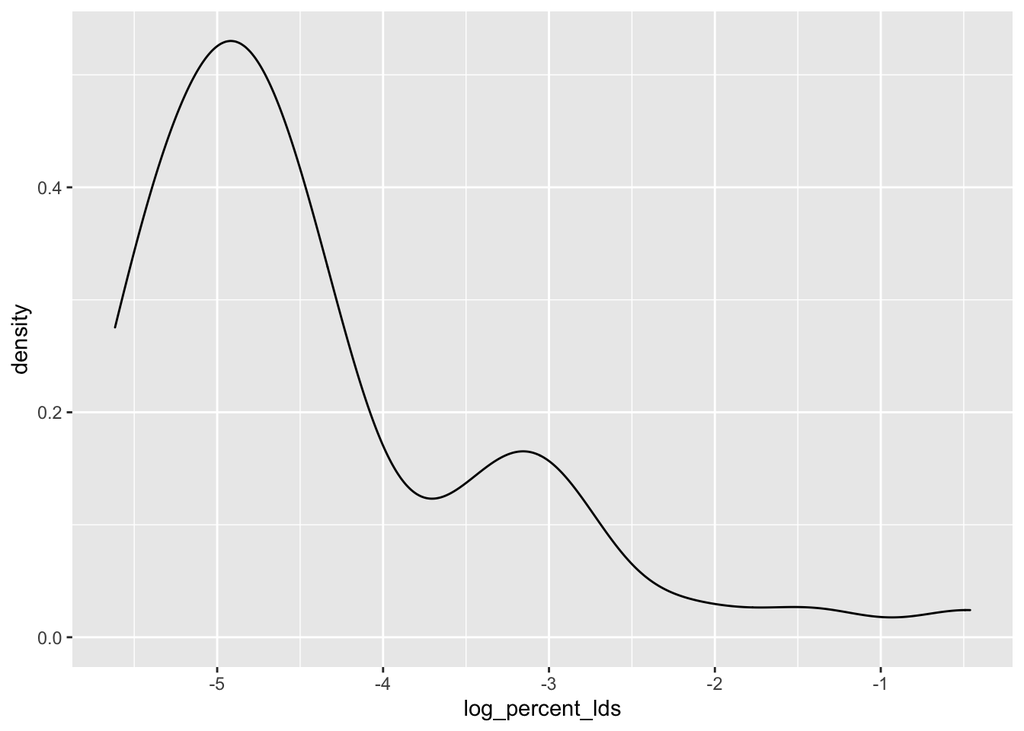

```r
# let's log percentage of Mormons and see if this changes
LDS_data <- LDS_data %>%
  mutate(log_percent_lds = log(percent_lds)) %>%
  select(State, log_percent_lds)

ggplot(LDS_data, aes(x = log_percent_lds)) + geom_density()
```

```r
# standardizing percentage to z scores
LDS_data <- LDS_data %>%
  mutate(across(c(log_percent_lds),
                ~ (.x - mean(.x)) / sd(.x)))
```

Now, let’s load in the `WaffleDivorce` data.

```r
data("WaffleDivorce")
waffle <- WaffleDivorce %>%
  mutate(State = Location) %>%
  mutate(across(c(MedianAgeMarriage, Marriage, Divorce),
                ~ (.x - mean(.x)) / sd(.x))) %>%
  select(State, MedianAgeMarriage, Marriage, Divorce)
```

Let’s join our data together.

```r
d5 <- full_join(waffle, LDS_data, by = "State") %>%
  drop_na() %>% # Nevada and D.C. had NAs so let's drop those
  rename(M = Marriage) %>%
  rename(D = Divorce) %>%
  rename(A = MedianAgeMarriage) %>%
  rename(L = log_percent_lds)
```

Now, let’s create our model definition.

$$\begin{align}
D_i &\sim Normal(\mu, \sigma)\\
\mu_i &= \alpha + \beta_LL_i + \beta_MM_i + \beta_AA_i\\
\alpha &\sim Normal(0,0.2) \\
\beta_L &\sim Normal(0,0.5) \\
\beta_M &\sim Normal(0,0.5) \\
\beta_A &\sim Normal(0,0.5) \\
\sigma &\sim Exponential(1)
\end{align}$$

Now, let’s do it in code and create quadratic approximation

```r
mormon_sim <- quap(
  alist(
    D ~ dnorm(mu, sigma),
    mu <- a + bL * L + bM * M + bA * A,
    a ~ dnorm(0, 0.2),
    bL ~ dnorm(0, 0.5),
    bM ~ dnorm(0, 0.5),
    bA ~ dnorm(0, 0.5),
    sigma ~ dexp(1)
  ),
  data = d5
)
precis(mormon_sim)
```

```
##               mean         sd       5.5%       94.5%
## a     -0.009786146 0.09585826 -0.1629862  0.14341386
## bL    -0.292123983 0.15293435 -0.5365426 -0.04770536
## bM     0.077202331 0.16948424 -0.1936662  0.34807087
## bA    -0.691608094 0.17419895 -0.9700117 -0.41320452
## sigma  0.759960314 0.07633836  0.6379569  0.88196377
```

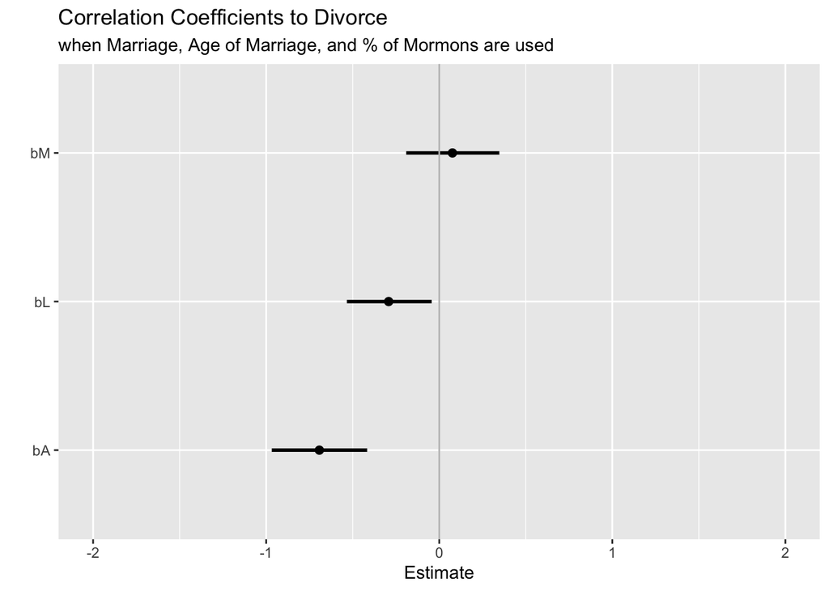

```r
# get samples
m_post <- tidy_draws(mormon_sim, n = 1e4) %>%
  select(bL, bM, bA)

# prepping to plot

m_longpost <- m_post %>%
  pivot_longer(everything(),
               names_to = "term",
               values_to = "values")

m_postsum <- m_longpost%>%
  group_by(term) %>%
  summarize(mean = mean(values), # taking means of the sampled parameters
            lb = quantile(values, .055),
            ub = quantile(values, .945))



# plotting

ggplot(m_postsum,
       aes(y = term,
           x = mean,
           xmin = lb,
           xmax = ub)) +
  geom_point(size = 2) +
  geom_linerange(size = 1) +
  geom_vline(xintercept = 0,
             color = "gray") +
  xlim(-2,2) +
  labs(x = "Estimate",
       y = "",
       title = "Correlation Coefficients to Divorce",
      subtitle = "when Marriage, Age of Marriage, and % of Mormons are used")
```

Like before, we see that marriage and divorce do not have a strong association while divorce and age of marriage do have a strong negative association. What is interesting is that we are now also able to see that divorce and percentage of LDS population *do* have a strong negative association like the question suggested.

**5M5. One way to reason through multiple causation hypotheses is to imagine detailed mechanisms through which predictor variables may influence outcomes. For example, it is sometimes argued that the price of gasoline (predictor variable) is positively associated with lower obesity rates (outcome variable). However, there are at least two important mechanisms by which the price of gas could reduce obesity. First, it could lead to less driving and therefore more exercise. Second, it could lead to less driving, which leads to less eating out, which leads to less consumption of huge restaurant meals. Can you outline one or more multiple regressions that address these two mechanisms? Assume you can have any predictor data you need.**

Let’s start by creating DAGs that show each relationship of gasoline (G), obesity rates (O), amount of driving (D), exercise (E), eating out (we’ll label as fast food - F).

(assuming we have this stuff available somehow) G = gasoline will be measured by prices O = obesity rates by county D = average amount of driving done E = amount of times people go to the gym F = fast food stops per week

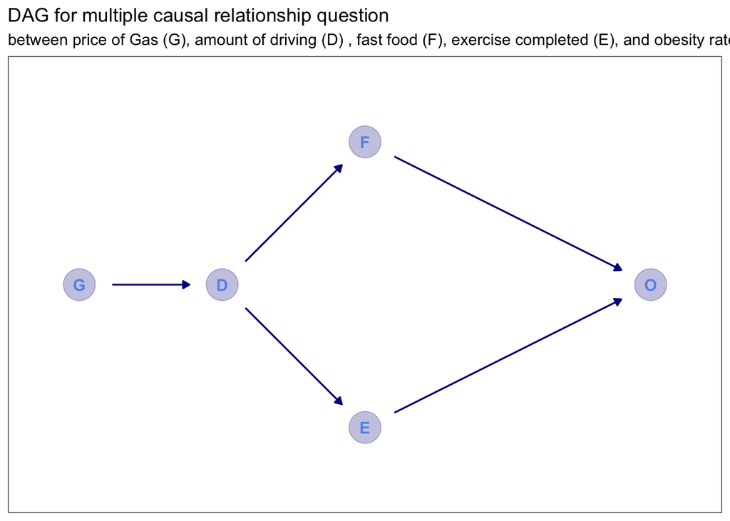

```r
dag_coords6 <-
  tibble(
    name = c("G", "D", "E", "F", "O"),
    x = c(G = 1, D = 2, E = 3, F = 3, O = 5),
    y = c(G = 2, D = 2, E = 1, F = 3, O = 2)
  )

p6 <-
  dagify(D ~ G, E ~ D, F ~ D,O ~ E + F,
    coords = dag_coords6
  ) %>%
  ggplot(aes(x = x, y = y, xend = xend, yend = yend)) +
  geom_dag_point(color = "blue4", alpha = 1 / 4, size = 10) +
  geom_dag_text(color = "cornflowerblue") +
  geom_dag_edges(edge_color = "blue4") +
  scale_x_continuous(NULL, breaks = NULL, expand = c(0.1, 0.1)) +
  scale_y_continuous(NULL, breaks = NULL, expand = c(0.2, 0.2)) +
  theme_bw() +
  theme(panel.grid = element_blank()) +
  labs(
    title = "DAG for multiple causal relationship question",
    subtitle = paste0(
      "between price of Gas (G), amount of driving (D) ",
      ", fast food (F), exercise completed (E), and obesity rate (O)"
    )
  )

p6
```

Here is how I would assign signs:  
G -> D (-): higher gas price lower amount of time driving  
D -> E (-): lower amount of time driving, more exercise  
E -> O (-): more exercise, less obesity  
D -> F (+): lower amount of time driving, lower rates of people eating out  
F -> O (+): less people eating out, less obesity

Additionally, I think my equation process would look something like this:  
First, I’d start with the assumed relationship.

$$\begin {align}
O_i &= Normal(\mu_i, \sigma)\\
\mu_i &\sim \alpha + \beta_GG_i \\
\end{align}$$
then check each path
$$\begin {align}
O_i &= Normal(\mu_i, \sigma)\\
\mu_i &\sim \alpha + \beta_GG_i + \beta_DD_i + \beta_EE_i\\
\end{align}$$
and
$$\begin {align}
O_i &= Normal(\mu_i, \sigma)\\
\mu_i &\sim \alpha +\beta_GG_i \ + \beta_DD_i + \beta_FF_i \\
\end{align}$$

and finally the full model.

$$\begin {align}
O_i &= Normal(\mu_i, \sigma)\\
\mu_i &\sim \alpha +\beta_GG_i \ + \beta_DD_i + + \beta_EE_i +
\beta_FF_i \\
\end{align}$$

I am assuming we should keep D and G with E and F because that is mechanistically how that part of the function works but we are seeing the differences between exercising or fast food as an impact on obesity. If the relationship from step one to checking the two paths is reduced instead of increased, then our beginnig assumption may be right.